# JOUR 8500 STM Demo

Namuun, Stasi & Jiarou

2026-02-16

## Structural Topic Modeling

This demo follows the SICSS topic modeling tutorial *starting from the STM package section*, using the *poliblogs** dataset and the `stm` workflow:

1. download data
2. preprocess text (`textProcessor`, `prepDocuments`)
3. fit STM with covariates (`rating`, `day`)
4. inspect topics (`plot`, `labelTopics`, `findThoughts`)
5. choose K (`searchK`)
6. estimate covariate effects (`estimateEffect`, `plot`)

### About STM

Latent Dirichlet Allocation (LDA) is one of the most common topic modeling methods, but several related approaches exist, such as Dynamic Topic Models, Correlated Topic Models, and Hierarchical Topic Models. One increasingly popular method is **Structural Topic Modeling (STM)**. STM is similar to LDA but has an important advantage: it **incorporates document metadata (such as author, date, or source)** to improve topic estimation and allow researchers to examine how topics vary across different document characteristics.

STM is supported by a R package called **`stm`**. This package not only fits structural topic models but also provides tools for preprocessing text, selecting the number of topics, validating models, and interpreting and visualizing results.

```r
# Setup
# Load package
library(stm)
```

```r
# Load data
google_doc_id <- "1LcX-JnpGB0lU1iDnXnxB6WFqBywUKpew" # google file ID
poliblogs<-read.csv(sprintf("https://docs.google.com/uc?id=%s&export=download", google_doc_id), stringsAsFactors = FALSE)
```

If you browse this dataframe, you’ll see that it not only includes the text of the blog posts, but also the names of the blog, the day of the year on which the blog post was produced, and a “conservative/liberal” label for each blog. We will use these variables later to demonstrate the power of meta-data for topic modeling.

### text pre-processing

Before we get into structural topic modeling, let’s try out the **`stm`** package’s text pre-processing functions. The **`textProcessor`** function automatically removes a) punctuation; b) stop words; c) numbers, and d) stems each word. The function requires us to specify the part of the dataframe where the documents we want to analyze are (ours are called **`documents`**), and it also requires us to name the dataset where the rest of the meta data live (**`poliblogs`**).

```r
## You may need to install the following packages if you conduct the text analysis for the first time
## install.packages("stm") don't do this in markdown
## install.packages(c("tm", "SnowballC")) "tm" is used to remove punctuation, convert to lowercases,...
## snowballc is used for stemming
```

```r
# Preprocess
processed <- textProcessor(poliblogs$documents, metadata = poliblogs)
```

```
## Building corpus...
## Converting to Lower Case...
## Removing punctuation...
## Removing stopwords...
## Removing numbers...
## Stemming...
## Creating Output...
```

Somewhat unusually, the **`stm`** package also requires us to store the documents, meta data, and “vocab”—or total list of words described in the documents—in separate objects (see code below).

```r
out <- prepDocuments(processed$documents, processed$vocab, processed$meta)
```

```
## Removing 83198 of 123990 terms (83198 of 2298953 tokens) due to frequency
## Your corpus now has 13246 documents, 40792 terms and 2215755 tokens.
```

```r
# You can also manually adjust the threshold of deletion. For example, here only words that appear in at least five documents are retained
out_2 <- prepDocuments(processed$documents, processed$vocab,
                     processed$meta, lower.thresh = 5)
```

```
## Removing 106354 of 123990 terms (147987 of 2298953 tokens) due to frequency
## Your corpus now has 13246 documents, 17636 terms and 2150966 tokens.
```

```r
docs <- out$documents
vocab <- out$vocab
meta <-out$meta
```

### Determine the parameters and run the model

What we should specify here: - the number of topics - how to use meta data - the type of initialization or randomization that should be used: Random or **Spectral** (setting the seed)

This model uses both the “rating” variable (that describes whether the blog is liberal or conservative) as well as the day or date variable to improve topic classification. Note that the choice of variables used at this stage can be very consequential– in this case, we may fail to identify certain topics that appear on both liberal and conservative blogs (or wrongly conclude that they are separate issues).

```r
# We use "s(day)" rather than "day", as we assume that the prevalence of topic might have ups and downs across time
First_STM <- stm(documents = out$documents, vocab = out$vocab,
              K = 10, prevalence =~ rating + s(day) ,
              max.em.its = 75, data = out$meta,
              init.type = "Spectral", verbose = FALSE)
```

You may notice that this code takes quite a while to run depending upon your machine. Once again, we can begin to inspect our results by browsig the top words associated with each topic. The **`stm`** package has a useful function that visualizes these results called **`plot`**:

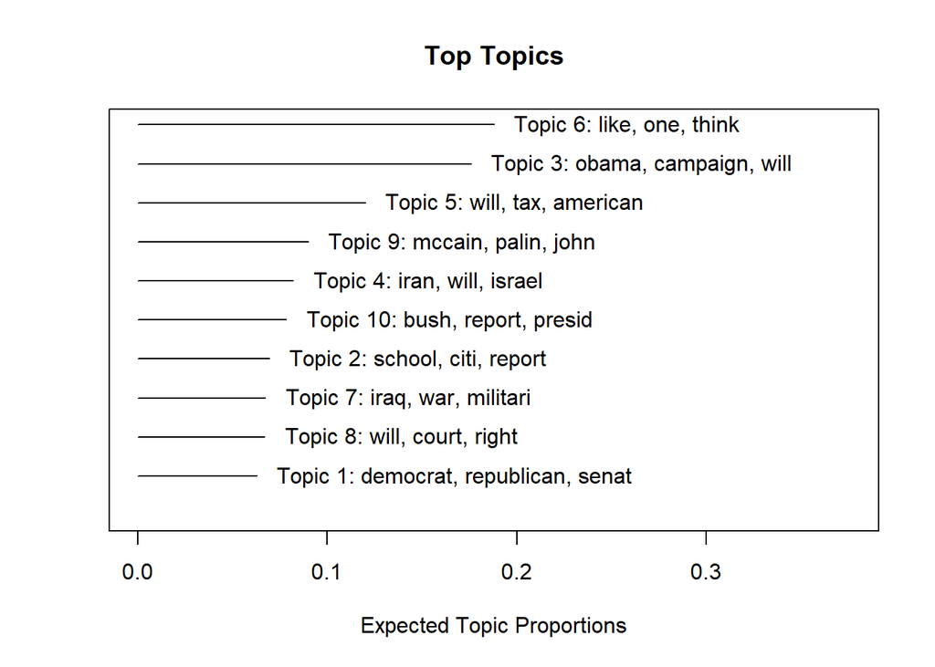

```r
plot(First_STM)
```

This visualization describes the prevalence of the topic within the entire corpus as well as the top three words associated with the topic. In this example, you may see that there are some topics that seem plausible, but many others that do not seem very coherent or meaningful.

### Problem 1

- Fit a new STM with K = 5 (keep the same prevalence formula: ~ rating + s(day)).
- Plot the model.
- Use labelTopics() to inspect top words for topics that look meaningful.

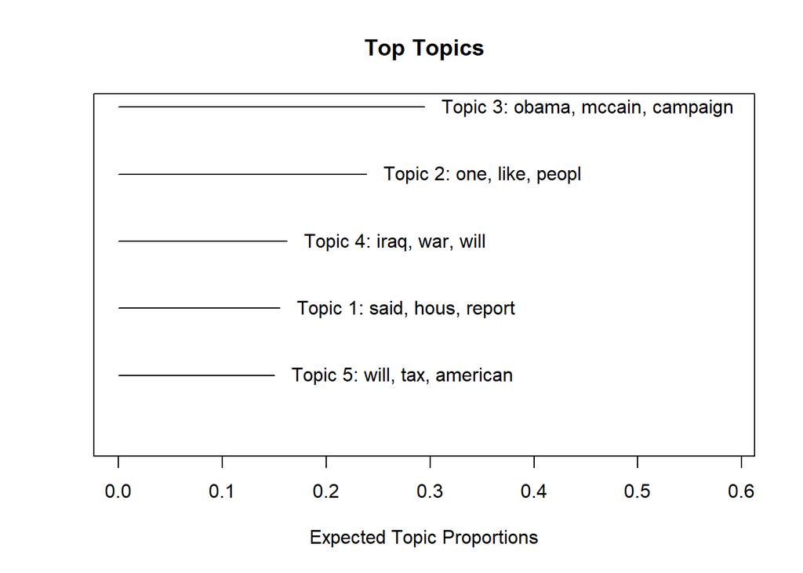

```r
# YOUR CODE HERE
STM_K5 <- stm(documents = out$documents, vocab = out$vocab,
              K = 5, prevalence = ~ rating + s(day),
              max.em.its = 75, data = out$meta,
              init.type  = "Spectral", verbose    = FALSE)

plot(STM_K5)
```

```r
labelTopics(STM_K5, n = 10)
```

```
## Topic 1 Top Words:
##       Highest Prob: said, hous, report, bush, senat, presid, state, sen, law, mccain
##       FREX: blagojevich, telecom, thinkfast, aye, subpoena, d-ca, siegelman, kbr, fratto, goodl
##       Lift: -apr-, -feb-, -growth, -mar-, ‘bridg, ‘climat, ‘econom, ‘nation, ‘resist, ‘special
##       Score: blagojevich, aye, sen, attorney, rep, feder, investig, perino, r-az, legisl
## Topic 2 Top Words:
##       Highest Prob: one, like, peopl, time, just, know, think, say, get, polit
##       FREX: taser, usmc, film, filmmak, cpl, ustream, solzhenitsyn, hartley, genr, rss
##       Lift: -speed, “art”, “cool”, “corrupt”, “eswinner”, “extreme”, “fitna”, “genuin, “gulag”, “honor
##       Score: usmc, film, wright, ayer, taser, church, palin, cathol, cpl, jeremiah
## Topic 3 Top Words:
##       Highest Prob: obama, mccain, campaign, democrat, will, barack, republican, clinton, vote, hillari
##       FREX: superdeleg, hillari, huck, romney, veep, wolfson, mitt, rasmussen, plouff, super-deleg
##       Lift: --charact, --die, -aug, -box, -command, -organ, -over, -percent-truth, -populist, -topic
##       Score: obama, hillari, mccain, poll, voter, republican, clinton, campaign, gop, vote
## Topic 4 Top Words:
##       Highest Prob: iraq, war, will, militari, american, said, bush, presid, govern, iran
##       FREX: iran, iranian, pakistan, hama, taliban, petraeus, pakistani, nato, maliki, missil
##       Lift: anbar, ceasefir, -iraqi, -million-ayear, -nation, -negoti, -rapid, -strong, -troop, -want
##       Score: iran, iraqi, israel, iranian, iraq, maliki, hama, sadr, pakistan, afghanistan
## Topic 5 Top Words:
##       Highest Prob: will, tax, american, year, govern, can, peopl, econom, make, new
##       FREX: qur’, solar, sura, ethanol, mortgag, fanni, lender, market, trillion, tax
##       Lift: -bailout, -compet, -encompass, -next, -stock, -strings-attach, -teach, -then, -vers, ‘abba
##       Score: tax, billion, mortgag, economi, oil, bailout, loan, qur’, drill, econom
```

### Interpret the results

The **`stm`** package has another useful function called **`findThoughts`** which extracts passages from documents within the corpus that load high on topics specified by the user.

```r
# n refers to the number of "representative work"
# To check multiple topics at a time, you can write it as: topics = c(1,2,3)
findThoughts(First_STM, texts = poliblogs$documents,
     n = 2, topics = 3)
```

```
##
##  Topic 3:
##       So what will happen tomorrow in the Indiana and North Carolina primaries?  If you look at the totality of all the polls thus far, they suggest that in terms of both the pledged del count and popular vote, an Obama win in North Carolina will be nearly canceled out by a corresponding Hillary …
##      A surge by Barack Obama has allowed him to leap  ahead or pull even in several states he trailed badly in last week which means that it is likely neither he or Hillary Clinton will come out of Super Tuesday with a large lead in delegates.According to published polls and analysts in the know,…
```

### Choosing a Value for k**

The **`stm`** package has a useful function called **`searchK`** which allows the user to specify a range of values for **`k`**, runs STM models for each value of ‘k’, and then outputs multiple goodness-of-fit measures that are very useful in identifying a range of values of **`k`** that provide the best fit for the data.

The syntax of this function is very similar to the **`stm`** function, except that the user specifies a range for **`k`** as one of the arguments. In the code below, we search all values of **`k`** between 5 and 30.

(Note: Running **`searchK`** on this corpus takes approximately seven hours. In the interest of saving time, you can plot the output of **`searchk`** using the load call below.)

**NOTE:** These codes were not executed due to the long runtime and computer configuration required.

```r
#findingk <- searchK(out$documents, out$vocab, K = c(5:30),
#prevalence =~ rating + s(day), data = meta, verbose=FALSE)

# Another compromise can be trying sequence with larger interval first
# findingk_2 <- searchK(out$documents, out$vocab,
                    #K = c(5, 10, 15, 20),
                    #prevalence =~ rating + s(day),
                    #data = meta,
                    #verbose = FALSE)
```

```r
#load("./findingk.Rda")
#plot(findingk)
```

We can compare the goodness-of-fit to decide which k range is better - Held-out likelihood: higher -> better - Residuals: lower -> better - Semantic coherence: higher -> better - Lower bound: higher -> better

Once again, readers should note that these measures are very imperfect, and are **not a superior alternative to human validation of the topic models** by carefully inspecting not only the top words associated with each document, but also conducting more focused analyses of the documents themselves.

## Working with Meta-Data

One of the principal advantages of STM is that one can examine the relationship between topics and various covariates of interest. Here we use the **`estimateEffect`** function to examine the relationship between the liberal/conservative **`rating`** variable and the first 10 topics, as well as time (**`day`**).

```r
predict_topics<-estimateEffect(formula = 1:10 ~ rating + s(day), stmobj = First_STM, metadata = out$meta, uncertainty = "Global")
```

Once we have the model, we can plot the relationships. The code below picks three topics and plots them according to their association with the liberal/conservative rating variable.

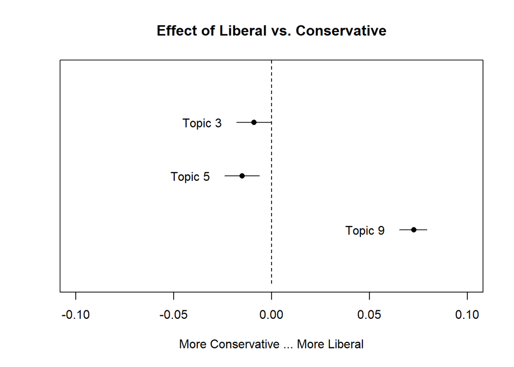

```r
plot(predict_topics, covariate = "rating", topics = c(3, 5, 9),
 model = First_STM, method = "difference",
 cov.value1 = "Liberal", cov.value2 = "Conservative",
 xlab = "More Conservative ... More Liberal",
 main = "Effect of Liberal vs. Conservative",
 xlim = c(-.1, .1), labeltype = "custom",
 custom.labels = c('Topic 3', 'Topic 5','Topic 9'))
```

### Problem 2

- Use estimateEffect() with the STM with k5 model you created in Problem 1.
- Choose 2 topics and plot the difference between Liberal and Conservative blogs.

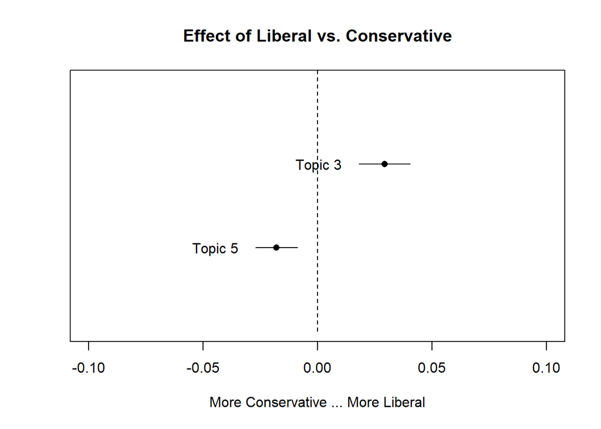

```r
# YOUR CODE HERE
predict_topics_K5<-estimateEffect(formula = 1:5 ~ rating + s(day), stmobj = STM_K5, metadata = out$meta, uncertainty = "Global")

plot(predict_topics_K5, covariate = "rating", topics = c(3, 5),
 model = STM_K5, method = "difference",
 cov.value1 = "Liberal", cov.value2 = "Conservative",
 xlab = "More Conservative ... More Liberal",
 main = "Effect of Liberal vs. Conservative",
 xlim = c(-.1, .1), labeltype = "custom",
 custom.labels = c('Topic 3', 'Topic 5'))
```

We can also plot change in the prevalence of topic over time. The code below plots change in the prevalence of topic 3.

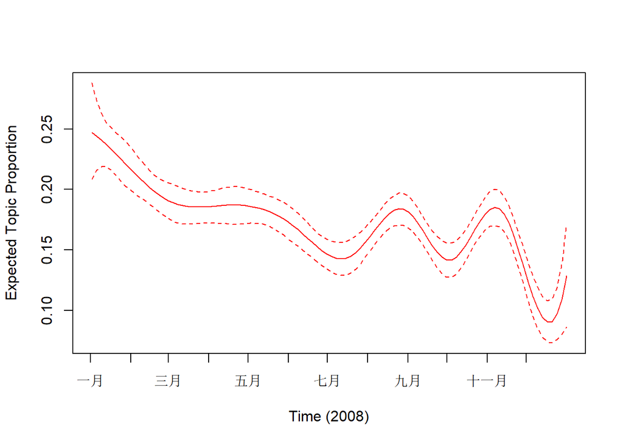

```r
plot(predict_topics, "day", method = "continuous", topics = 3,
model = z, printlegend = FALSE, xaxt = "n", xlab = "Time (2008)")
monthseq <- seq(from = as.Date("2008-01-01"),
to = as.Date("2008-12-01"), by = "month")
monthnames <- months(monthseq)
axis(1,at = as.numeric(monthseq) - min(as.numeric(monthseq)),
labels = monthnames)
```

```r
# You might find that your "month" label of the second plot is not in English.
# You can change the language to English following this
Sys.setlocale("LC_TIME", "English")
```

```
## [1] "English_United States.1252"
```

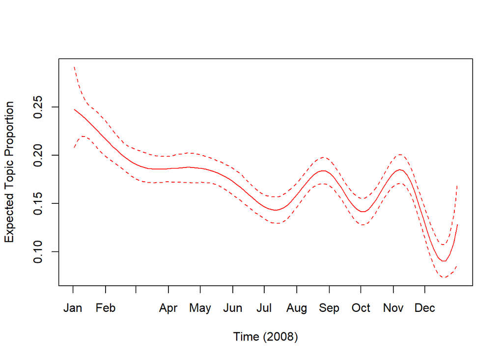

```r
# Mac/Linux, use "en_US.UTF-8"

monthseq <- seq(from = as.Date("2008-01-01"),
                to = as.Date("2008-12-01"), by = "month")
monthnames <- format(monthseq, "%b")

plot(predict_topics, "day", method = "continuous", topics = 3,
     model = First_STM, printlegend = FALSE, xaxt = "n", xlab = "Time (2008)")

axis(1, at = as.numeric(monthseq) - min(as.numeric(monthseq)),
     labels = monthnames)
```

### Problem 3

- Choose 1 topic in k5 model and plot how it changes over time.

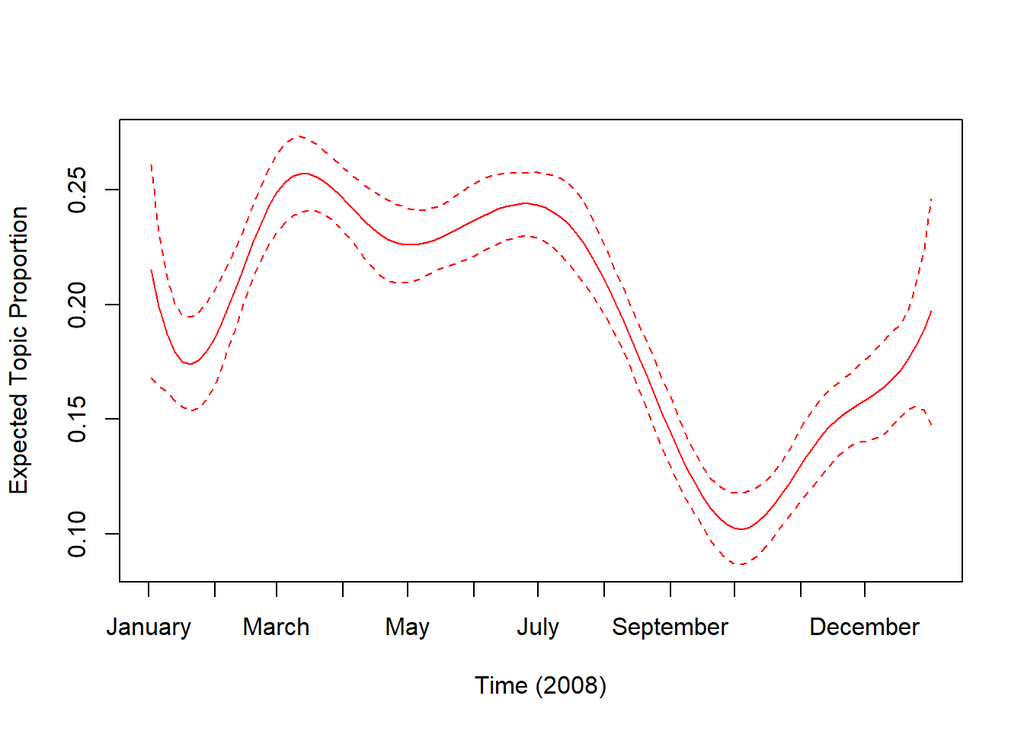

```r
# YOUR CODE HERE
plot(predict_topics_K5, "day", method = "continuous", topics = 4,
model = z, printlegend = FALSE, xaxt = "n", xlab = "Time (2008)")
monthseq <- seq(from = as.Date("2008-01-01"),
to = as.Date("2008-12-01"), by = "month")
monthnames <- months(monthseq)
axis(1,at = as.numeric(monthseq) - min(as.numeric(monthseq)),
labels = monthnames)
```

## Limitation

- You need to understand the text and your goal
- Ignore word order
- Might not be suitable for short text